# Customize plots of incidence

Thibaut Jombart, Zhian N. Kamvar

2020-03-25

This vignette provides some tips for the most common customisations of graphics produced by `plot.incidence`. Our graphics use *ggplot2*, which is a distinct graphical system from base graphics. If you want advanced customisation of your incidence plots, we recommend following an introduction to *ggplot2*.

# Example data: simulated Ebola outbreak

This example uses the simulated Ebola Virus Disease (EVD) outbreak from the package [*outbreaks*](http://github.com/reconhub/outbreaks): `ebola_sim_clean`.

First, we load the data:

```r
library(outbreaks)
library(ggplot2)
library(incidence)

onset <- ebola_sim_clean$linelist$date_of_onset
class(onset)
```

```
#> [1] "Date"
```

```r
head(onset)
```

```
#> [1] "2014-04-07" "2014-04-15" "2014-04-21" "2014-04-27" "2014-04-26"
#> [6] "2014-04-25"
```

We compute the weekly incidence:

```r
i <- incidence(onset, interval = 7)
i
```

```
#> <incidence object>
#> [5829 cases from days 2014-04-07 to 2015-04-27]
#> [5829 cases from ISO weeks 2014-W15 to 2015-W18]
#>
#> $counts: matrix with 56 rows and 1 columns
#> $n: 5829 cases in total
#> $dates: 56 dates marking the left-side of bins
#> $interval: 7 days
#> $timespan: 386 days
#> $cumulative: FALSE
```

```r
i.sex <- incidence(onset, interval = 7, group =  ebola_sim_clean$linelist$gender)
i.sex
```

```
#> <incidence object>
#> [5829 cases from days 2014-04-07 to 2015-04-27]
#> [5829 cases from ISO weeks 2014-W15 to 2015-W18]
#> [2 groups: f, m]
#>
#> $counts: matrix with 56 rows and 2 columns
#> $n: 5829 cases in total
#> $dates: 56 dates marking the left-side of bins
#> $interval: 7 days
#> $timespan: 386 days
#> $cumulative: FALSE
```

```r
i.hosp <- incidence(onset, interval = 7, group =  ebola_sim_clean$linelist$hospital)
i.hosp
```

```
#> <incidence object>
#> [5829 cases from days 2014-04-07 to 2015-04-27]
#> [5829 cases from ISO weeks 2014-W15 to 2015-W18]
#> [6 groups: Connaught Hospital, Military Hospital, other, Princess Christian Maternity Hospital (PCMH), Rokupa Hospital, NA]
#>
#> $counts: matrix with 56 rows and 6 columns
#> $n: 5829 cases in total
#> $dates: 56 dates marking the left-side of bins
#> $interval: 7 days
#> $timespan: 386 days
#> $cumulative: FALSE
```

# The `plot.incidence` function

When calling `plot` on an *incidence* object, the function `plot.incidence` is implicitly used. To access its documentation, use `?plot.incidence`. In this section, we illustrate existing customisations.

## Default behaviour

By default, the function uses grey for single time series, and colors from the color palette `incidence_pal1` when incidence is computed by groups:

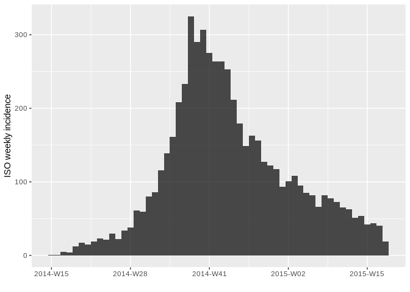

```r
plot(i)
```

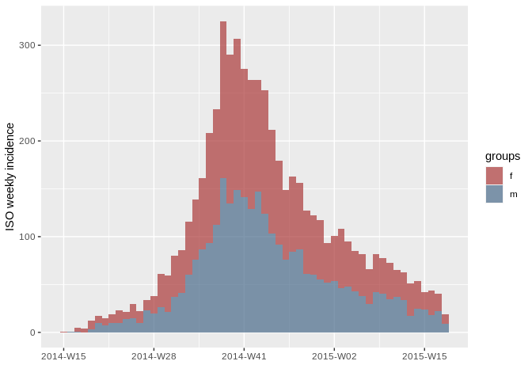

```r
plot(i.sex)
```

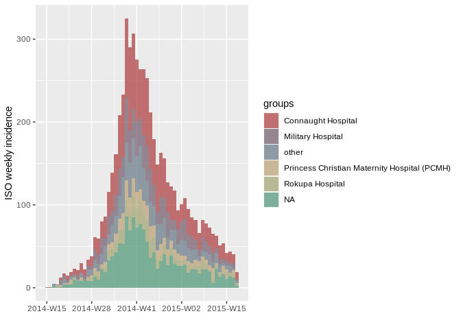

```r
plot(i.hosp)
```

However, some of these defaults can be altered through the various arguments of the function:

```r
args(incidence:::plot.incidence)
```

```
#> function (x, ..., fit = NULL, stack = is.null(fit), color = "black",
#>     border = NA, col_pal = incidence_pal1, alpha = 0.7, xlab = "",
#>     ylab = NULL, labels_week = !is.null(x$weeks), labels_iso = !is.null(x$isoweeks),
#>     show_cases = FALSE, n_breaks = 6)
#> NULL
```

## Changing colors

### The default palette

A color palette is a function which outputs a specified number of colors. By default, the color used in *incidence* is called `incidence_pal1`. Its behaviour is different from usual palettes, in the sense that the first 4 colours are not interpolated:

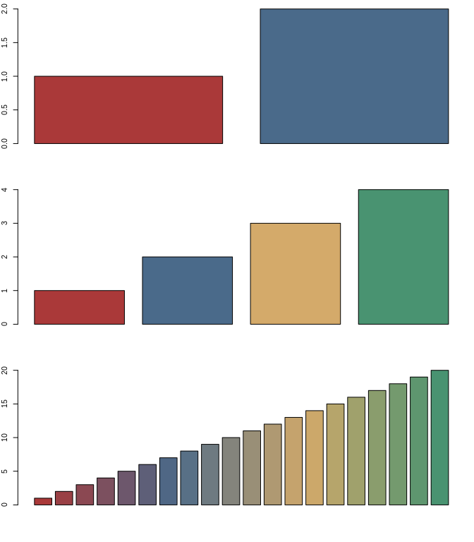

```r
par(mfrow = c(3, 1), mar = c(4,2,1,1))
barplot(1:2, col = incidence_pal1(2))
barplot(1:4, col = incidence_pal1(4))
barplot(1:20, col = incidence_pal1(20))
```

This palette also has a light and a dark version:

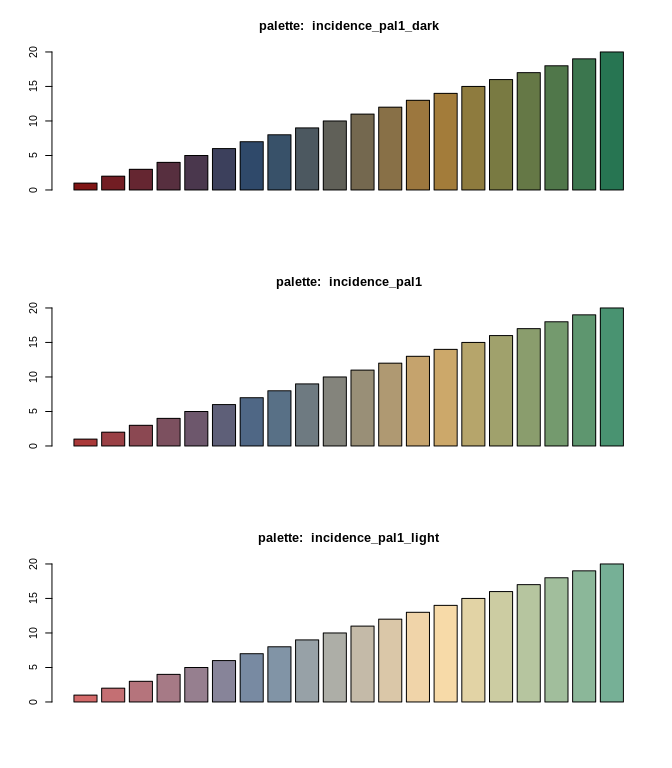

```r
par(mfrow = c(3,1))
barplot(1:20, col = incidence_pal1_dark(20), main = "palette:  incidence_pal1_dark")
barplot(1:20, col = incidence_pal1(20), main = "palette:  incidence_pal1")
barplot(1:20, col = incidence_pal1_light(20), main = "palette:  incidence_pal1_light")
```

### Using different palettes

Other color palettes can be provided via `col_pal`. Various palettes are part of the base R distribution, and many more are provided in additional packages. We provide a couple of examples:

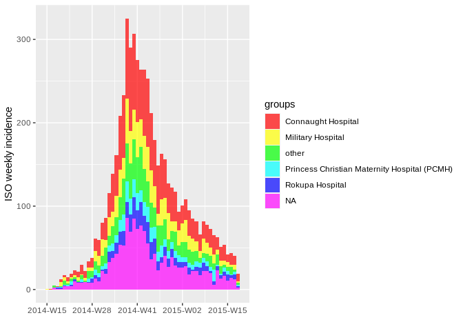

```r
plot(i.hosp, col_pal = rainbow)
```

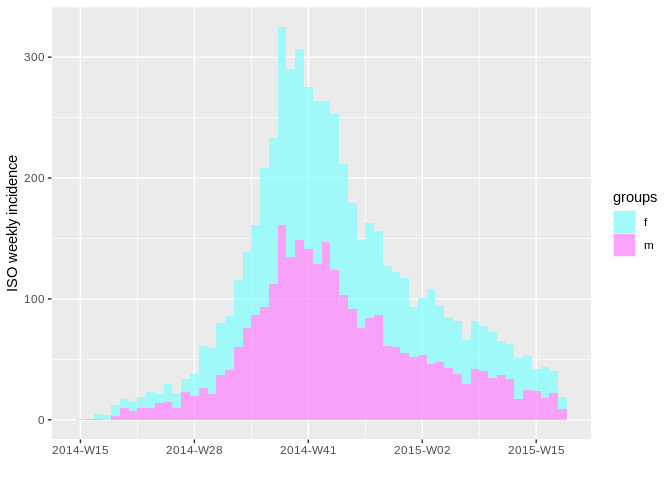

```r
plot(i.sex, col_pal = cm.colors)
```

### Specifying colors manually

Colors can be specified manually using the argument `color`; note that whenever incidence is computed by groups, the number of colors must match the number of groups, otherwise `color` is ignored.

#### Example 1: changing a single color

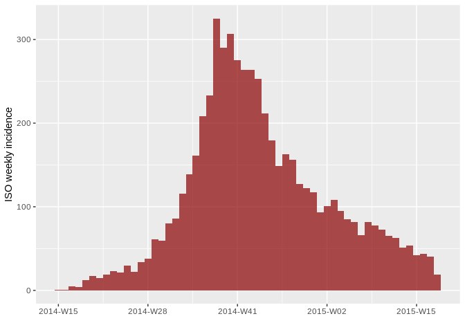

```r
plot(i, color = "darkred")
```

#### Example 2: changing several colors (note that naming colors is optional)

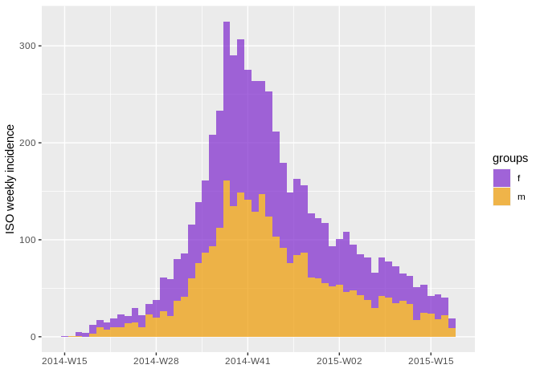

```r
plot(i.sex, color = c(m = "orange2", f = "purple3"))
```

#### Example 3: using color to highlight specific groups

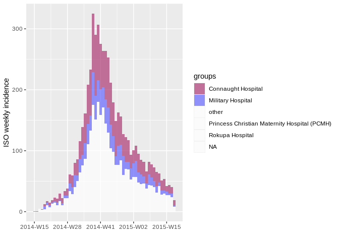

```r
plot(i.hosp,
     color = c("#ac3973", "#6666ff", "white", "white", "white", "white"))
```

# Useful *ggplot2* tweaks

Numerous tweaks for *ggplot2* are documented online. In the following, we merely provide a few useful tips in the context of *incidence*.

## Changing dates on the *x*-axis

### Changing date format

By default, the dates indicated on the *x*-axis of an incidence plot may not have the suitable format. The package *scales* can be used to change the way dates are labeled (see `?strptime` for possible formats):

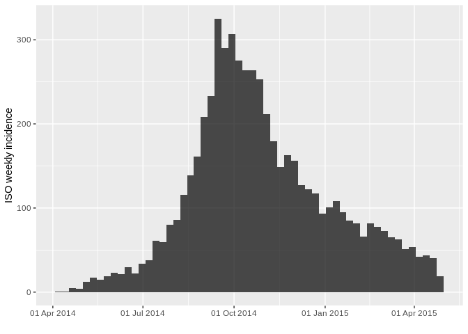

```r
library(scales)
plot(i, labels_week = FALSE) +
   scale_x_date(labels = date_format("%d %b %Y"))
```

Notice how the labels are all situated at the first of the month? If you want to make sure the labels are situated in a different orientation, you can use the `make_breaks()` function to calculate breaks for the plot:

```r
b <- make_breaks(i, labels_week = FALSE)
b
```

```
#> $breaks
#> [1] "2014-04-07" "2014-07-07" "2014-10-06" "2015-01-05" "2015-04-06"
#> [6] "2015-07-06"
#>
#> $labels
#> list()
#> attr(,"class")
#> [1] "waiver"
```

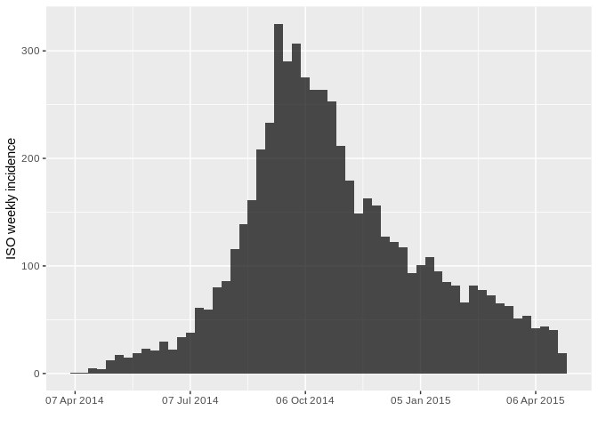

```r
plot(i) +
  scale_x_date(breaks = b$breaks,
               labels = date_format("%d %b %Y"))
```

And for another example, with a subset of the data (first 50 weeks), using more detailed dates and rotating the annotations:

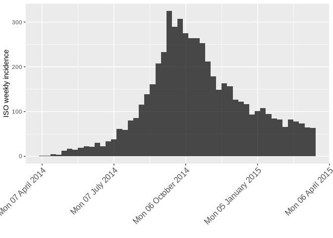

```r
plot(i[1:50]) +
  scale_x_date(breaks = b$breaks, labels = date_format("%a %d %B %Y")) +
  theme(axis.text.x = element_text(angle = 45, hjust = 1, size = 12))
```

Note that you can save customisations for later use:

```r
rotate.big <- theme(axis.text.x = element_text(angle = 45, hjust = 1, size = 12))
```

### Changing the grid

The last example above illustrates that it can be useful to have denser annotations of the *x*-axis, especially over short time periods. Here, we provide an example where we try to zoom on the peak of the epidemic, using the data by hospital:

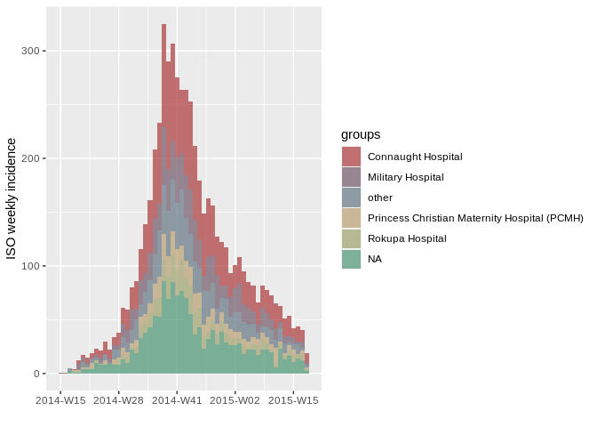

```r
plot(i.hosp)
```

Let us look at the data 40 days before and after the 1st of October:

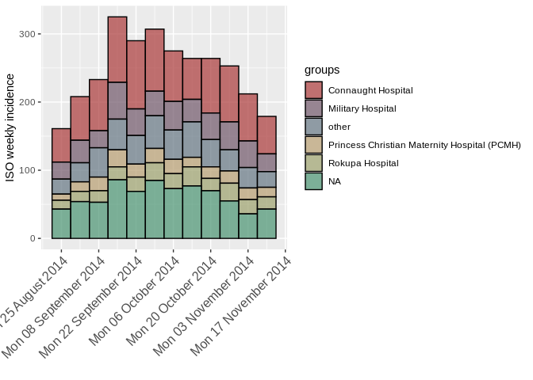

```r
period <- as.Date("2014-10-01") + c(-40, 40)
i.zoom <- subset(i.hosp, from = period[1], to = period[2])
detailed.x <- scale_x_date(labels = date_format("%a %d %B %Y"),
                           date_breaks = "2 weeks",
                           date_minor_breaks = "week")

plot(i.zoom, border = "black") + detailed.x + rotate.big
```

### Handling non-ISO weeks

If you have weekly incidence that starts on a day other than monday, then the above solution may produce breaks that fall inside of the bins:

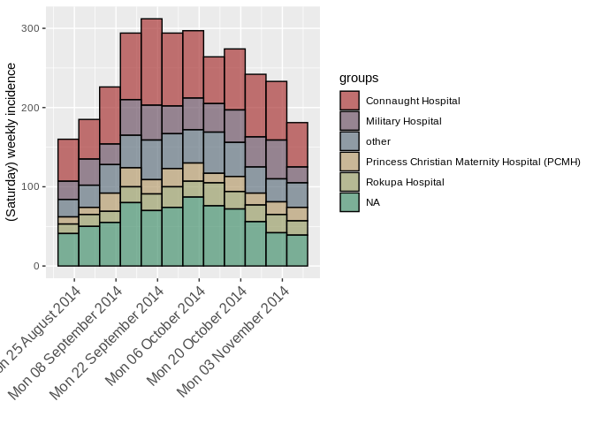

```r
i.sat <- incidence(onset, interval = "1 week: saturday", groups = ebola_sim_clean$linelist$hospital)
i.szoom <- subset(i.sat, from = period[1], to = period[2])

plot(i.szoom, border = "black") + detailed.x + rotate.big
```

In this case, you may want to either calculate breaks using `make_breaks()` or use the `scale_x_incidence()` function to automatically calculate these for you:

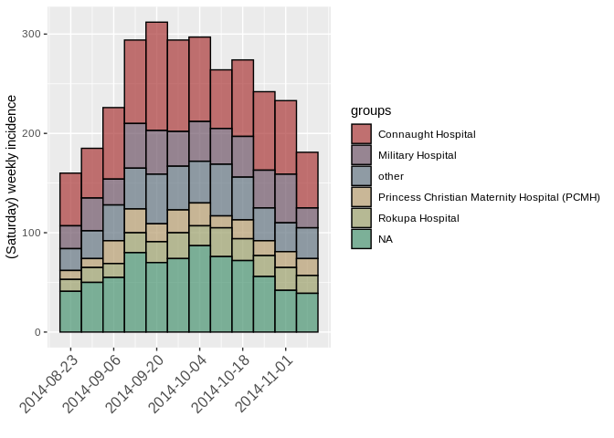

```r
plot(i.szoom, border = "black") +
  scale_x_incidence(i.szoom, n_breaks = nrow(i.szoom)/2, labels_week = FALSE) +
  rotate.big
```

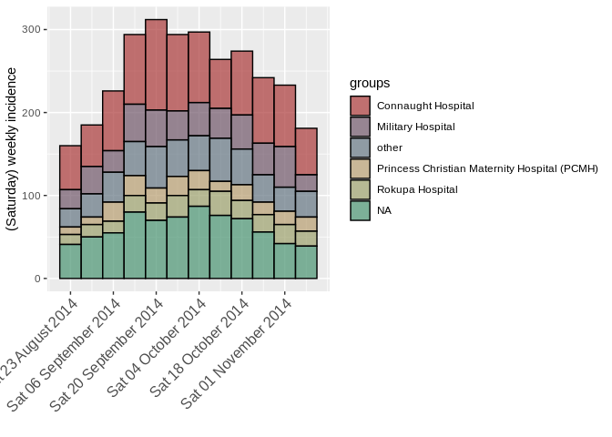

```r
sat_breaks <- make_breaks(i.szoom, n_breaks = nrow(i.szoom)/2)
plot(i.szoom, border = "black") +
  scale_x_date(breaks = sat_breaks$breaks, labels = date_format("%a %d %B %Y")) +
  rotate.big
```

### Labelling every bin

Sometimes you may want to label every bin of the incidence object. To do this, you can simply set `n_breaks` to the number of rows in your incidence object:

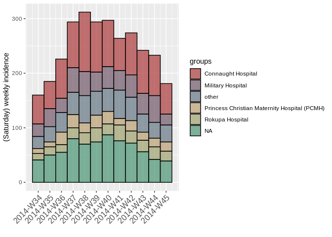

```r
plot(i.szoom, n_breaks = nrow(i.szoom), border = "black") + rotate.big
```

## Changing the legend

The previous plot has a fairly large legend which we may want to move around. Let us save the plot as a new object `p` and customize the legend:

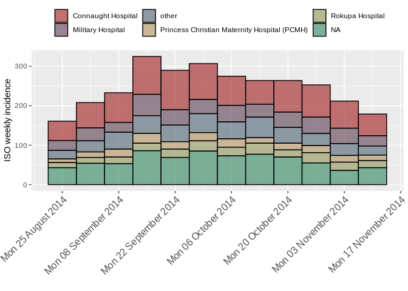

```r
p <- plot(i.zoom, border = "black") + detailed.x + rotate.big
p + theme(axis.text.x = element_text(angle = 45, hjust = 1, size = 12),
          legend.position = "top", legend.direction = "horizontal",
          legend.title = element_blank())
```

## Applying the style of European Programme for Intervention Epidemiology Training (EPIET)

### Display individual cases

For small datasets it is convention of EPIET to display individual cases as rectangles. It can be done by doing two things: first, adding using the option `show_cases = TRUE` with a white border and second, setting the background to white. We also add `coord_equal()` which forces each case to be a square.

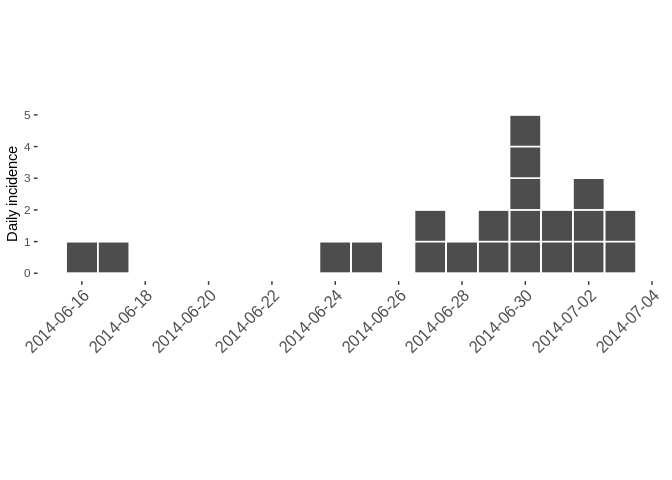

```r
i.small <- incidence(onset[160:180])

plot(i.small, border = "white", show_cases = TRUE) +
  theme(panel.background = element_rect(fill = "white")) +
  rotate.big +
  coord_equal()
```